```python
import pandas as pd
import numpy as np
import matplotlib.pyplot as plt
```

```python
sf_data = pd.read_csv("/home/divyanshu/datasci_course_materials/assignment6/sanfrancisco_incidents_summer_2014.csv")
sf_data['Time'] = pd.to_datetime(sf_data['Time'],format= '%H:%M' ).dt.time
```

# Analysis of Various Categories

### Larceny/Theft is the most common crime in San Francisco. Other common crimes are "Other Offenses", "Non-Criminal", "Assault", etc.

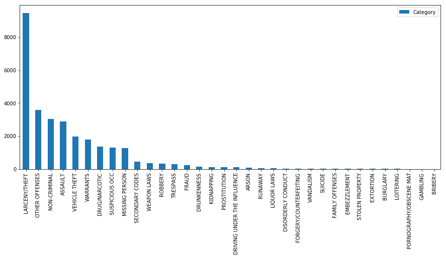

```python
category_counts = sf_data['Category'].value_counts()
plt.figure(figsize = (15,6)); category_counts.plot.bar(legend=True); plt.show()
```

```python
important_categories = ['LARCENY/THEFT','OTHER OFFENSES', 'NON-CRIMINAL', 'ASSAULT', 'VEHICLE THEFT',
                       'WARRANTS','DRUG/NARCOTIC', 'SUSPICIOUS OCC','MISSING PERSON']
```

# Analysing categories on the basis of Time

### The crimes are very common during the evening hours, though there is a spike in noon, overall, the crime rate is high in the evening till night.

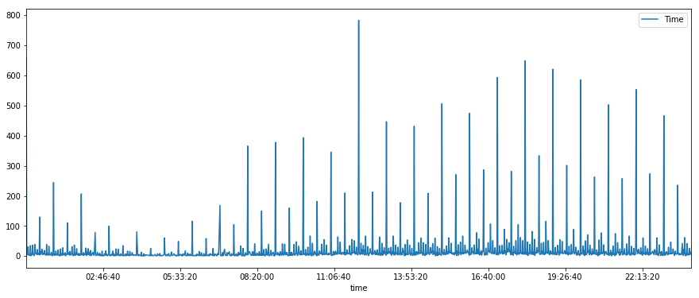

```python
total_time_counts = sf_data["Time"].value_counts()
plt.figure(figsize = (15,6)); total_time_counts.plot.line(legend=True); plt.show()
```

# Analysing relationship of crime category with Districts

### Southern, Mission and Northern are leading in crime rates and contribute to about 50% of all crimes in San Francisco

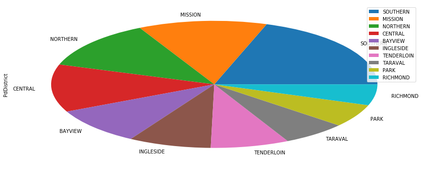

```python
category_counts = sf_data['PdDistrict'].value_counts()
plt.figure(figsize = (15,6)); category_counts.plot.pie(legend=True); plt.show()
```

# District wise analysis of Crimes

### BayView, Mission has the most crimes in Larceny and Other Offenses. Southern District has an enormous amount of Larceny Crimes while other crimes are negligble as compared to Larceny/Theft. Richmond, Central, Park, Taraval and Northern has a similar pattern.

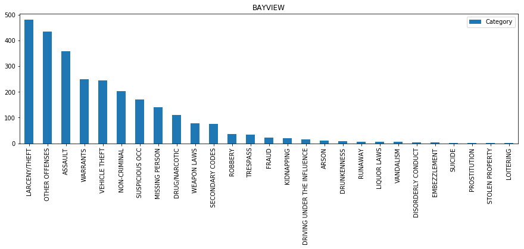

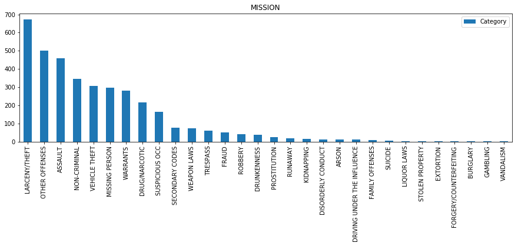

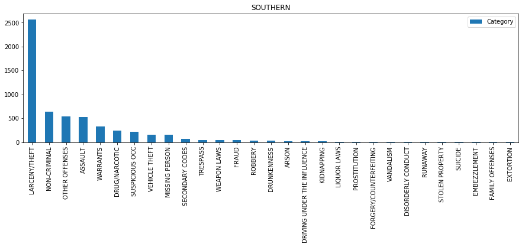

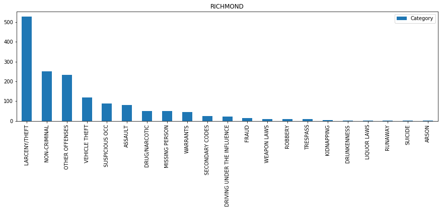

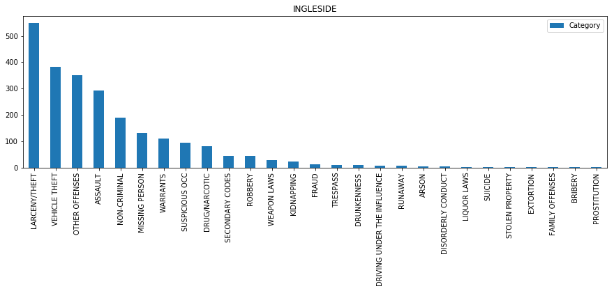

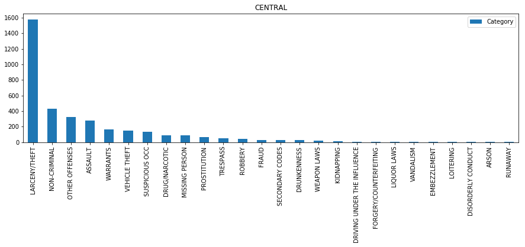

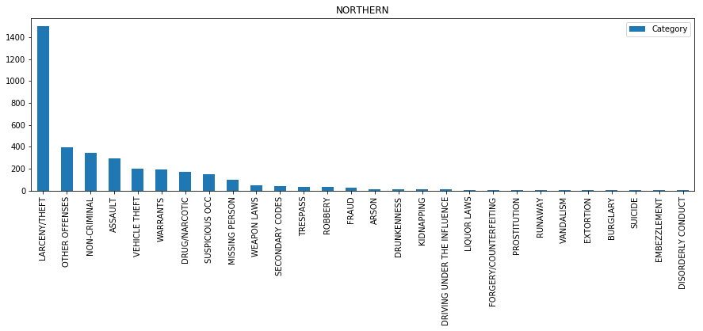

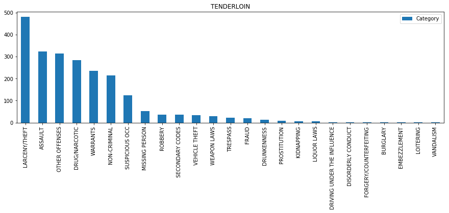

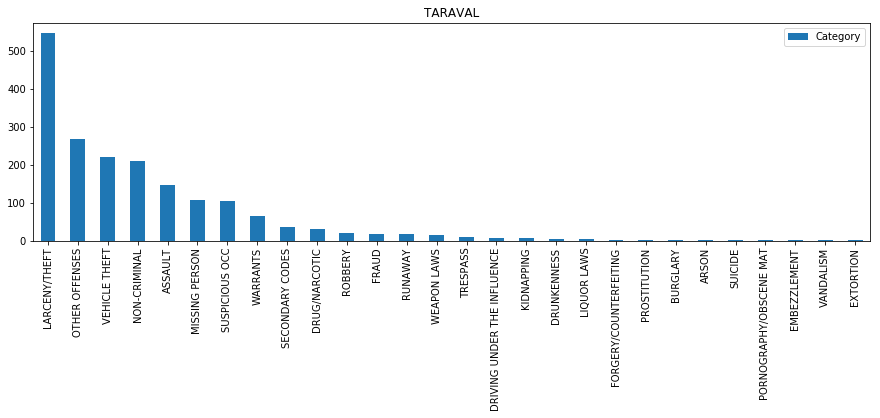

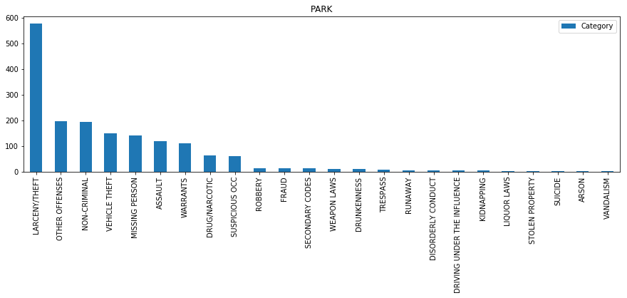

```python
for district in sf_data.PdDistrict.unique():
    df = sf_data.loc[sf_data["PdDistrict"]==district]
    c_counts = df["Category"].value_counts()
    plt.figure(figsize = (15,4)); c_counts.plot.bar(legend=True, title=district); plt.show()
```

# Analysing relationship of crime category with Time and Districts

### Larceny/Theft is very frequent post 5 in the evening. Other Offenses crime is common during the noon. Non-Criminal ,Assault and Warrant crimes are spread throughout the day evenly. Vehicle theft is frequent in late evening and night .

### Analysing on the district level, Southern is leading in Larceny, Other offenses, Non-Criminal, Assault, Warrants and Suspicious OCC. Missing Person is very common in Mission distirct as compared to other districts. Drug Narcotic is high in Tenderloin , Southern and Mission.

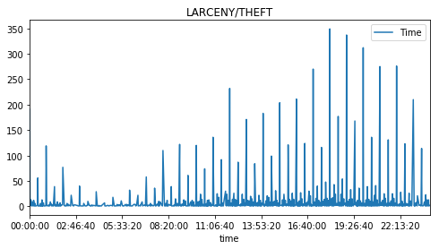

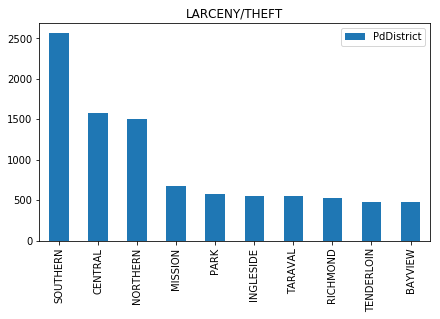

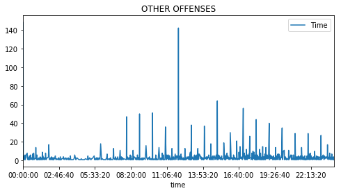

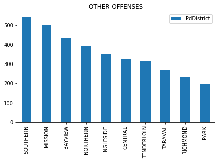

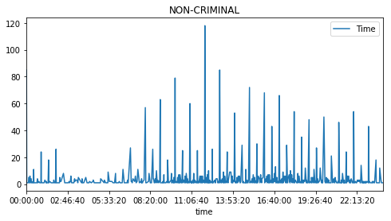

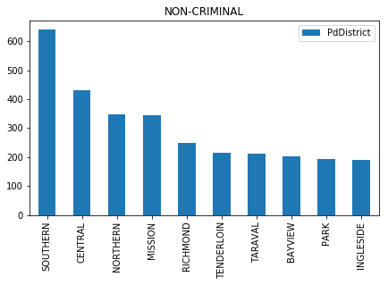

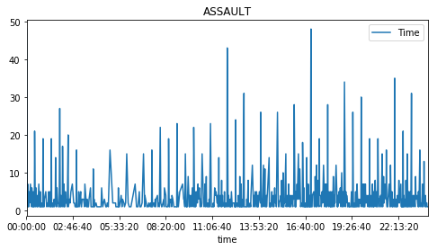

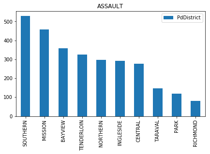

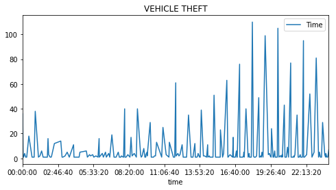

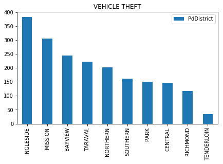

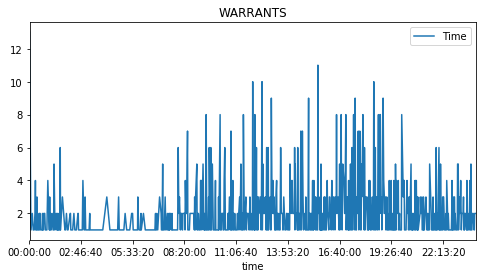

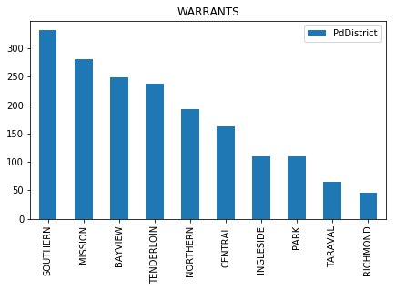

[6 more figures not shown]

```python
for category in important_categories:
    df = sf_data.loc[sf_data["Category"]==category]
    time_counts = df["Time"].value_counts()
    plt.figure(figsize = (8,4)); time_counts.plot(legend=True, title=category); plt.show()
    dis_counts = df["PdDistrict"].value_counts()
    plt.figure(figsize=(7,4)); dis_counts.plot.bar(legend=True, title=category); plt.show()
```